# Module 03: Measurement — Exploratory and Confirmatory Factor Analysis

Computational Social Science — Graduate & Undergraduate

2026-04-04

# 1 Overview: Why Measurement Matters

Before you can study relationships between constructs — do political values predict civic engagement? does stress cause health decline? — you need to establish that you are actually measuring those constructs. This is the measurement problem, and it is harder than it looks.

The things social scientists most care about — personality, intelligence, ideology, wellbeing, social capital, cultural capital — are **latent variables**: theoretical constructs that cannot be directly observed but must be inferred from their effects on observable indicators. You cannot see “neuroticism” directly. You can see that a person worries frequently, gets irritated easily, has frequent mood swings, and often feels blue. Those four responses, taken together, give you information about an underlying tendency you call neuroticism.

Factor analysis is the primary tool for modelling latent variables. It exists in two forms:

- **EFA (Exploratory Factor Analysis):** Used when you do not know (or want to discover) the factor structure. You let the data tell you how many factors there are and which items belong to which.
- **CFA (Confirmatory Factor Analysis):** Used when you have a theoretically specified factor structure and want to test whether it fits the data.

**Learning goals:**

- Explain what a latent variable is and why averaging items is not equivalent
- Check whether data is suitable for factor analysis (KMO, Bartlett)
- Run EFA, decide on the number of factors, choose a rotation, and read every element of the output
- Specify and fit a CFA in lavaan
- Read and interpret the full lavaan CFA output, section by section
- Evaluate model fit using the standard indices with their benchmarks
- Compute reliability with Cronbach’s alpha and McDonald’s omega

# 2 The Measurement Problem

## 2.1 Why You Cannot Just Average Items

Suppose you want to measure “social trust” using three survey items:

1. “Most people can be trusted.” (1–5 agree)
2. “People try to be helpful.” (1–5 agree)
3. “Most people are fair.” (1–5 agree)

A common approach is to sum or average these: `trust_score = (item1 + item2 + item3) / 3`. This is called a **composite score**. It has several problems:

- It treats all three items as equally informative — but some items may be better indicators of the underlying construct than others.
- It assumes all measurement error is random — but items can have systematic biases (e.g., item 1 is susceptible to mood effects not related to trust).
- It gives no information about how reliably the composite measures the construct.
- It cannot tell you whether the three items are actually measuring the same underlying thing.

Factor analysis solves all of these problems. Instead of assuming equality, it *estimates* the relationship between each item and the underlying factor. Instead of ignoring error, it explicitly models it. Instead of assuming a single factor, it tests whether one factor fits the data.

## 2.2 The Latent Variable Model

The single-factor model says:
$$y_i =
\lambda_i \eta + \varepsilon_i$$

- $y_i$: the observed score on item $i$
- $\eta$: the latent factor (unobserved; what you actually want to measure)
- $\lambda_i$: the **factor loading** — how strongly item $i$ is related to $\eta$
- $\varepsilon_i$: **unique variance** — the part of item $i$ not explained by $\eta$ (measurement error + item-specific content)

The **communality** of item $i$ is $h_i^2 = \lambda_i^2$ (in standardised form) — the proportion of item variance explained by the factor. The **uniqueness** is $u_i^2 = 1 - h_i^2$ — the proportion *not* explained.

**Local independence** is the key assumption: within a given level of $\eta$, the items are uncorrelated. All item intercorrelations arise from the shared latent factor. If two items remain correlated after controlling for the factor, the model is misspecified.

# 3 The IPIP Big Five Dataset

We use `bfi` from the `psych` package: 2,800 participants × 25 personality items + demographics. Items measure the Big Five personality traits (OCEAN: Openness, Conscientiousness, Extraversion, Agreeableness, Neuroticism), 5 items each, on a 6-point scale (1 = Very Inaccurate, 6 = Very Accurate).

```r
library(psych)
data(bfi)

cat("Dataset dimensions:", nrow(bfi), "participants ×", ncol(bfi), "variables\n")
```

```
## Dataset dimensions: 2800 participants × 28 variables
```

```r
cat("First 25 columns: personality items (A1–A5, C1–C5, E1–E5, N1–N5, O1–O5)\n")
```

```
## First 25 columns: personality items (A1–A5, C1–C5, E1–E5, N1–N5, O1–O5)
```

```r
cat("Remaining: gender, education, age\n\n")
```

```
## Remaining: gender, education, age
```

```r
# A quick look at one item to understand the scale
cat("Distribution of item E3 ('Know how to captivate people'):\n")
```

```
## Distribution of item E3 ('Know how to captivate people'):
```

```r
table(bfi$E3, useNA="ifany") |> print()
```

```
##
##    1    2    3    4    5    6 <NA>
##  149  293  412  826  743  352   25
```

```r
cat("Scale: 1=Very Inaccurate, 6=Very Accurate\n")
```

```
## Scale: 1=Very Inaccurate, 6=Very Accurate
```

[output not shown]

```r
# Extract the 25 personality items; remove cases with any missing
bfi_items    <- bfi[, 1:25]
bfi_complete <- na.omit(bfi_items)

cat("Total respondents:    ", nrow(bfi_items), "\n")
```

```
## Total respondents:     2800
```

```r
cat("Complete cases:        ", nrow(bfi_complete), "\n")
```

```
## Complete cases:         2436
```

```r
cat("Dropped (any NA):     ", nrow(bfi_items) - nrow(bfi_complete), "\n")
```

```
## Dropped (any NA):      364
```

```r
cat("Loss rate:            ", round((nrow(bfi_items)-nrow(bfi_complete))/nrow(bfi_items)*100,1), "%\n")
```

```
## Loss rate:             13 %
```

# 4 Part A: Exploratory Factor Analysis

## 4.1 Step 1 — Check Factorability

Before running EFA, check whether the data is suitable. Two standard tests:

**KMO (Kaiser-Meyer-Olkin):** Measures whether the correlation patterns are compact enough to yield reliable factors. Values range from 0 to 1. Interpretation: ≥ .90 = “Marvelous”, ≥ .80 = “Meritorious”, ≥ .70 = “Middling”, ≥ .60 = “Mediocre”, < .50 = “Unacceptable — do not factor analyse.”

**Bartlett’s test of sphericity:** Tests H₀: the correlation matrix is an identity matrix (all correlations = 0). A significant result means correlations are present. With large N this is almost always significant — treat it as a minimum sanity check, not a strong criterion.

```r
kmo_res <- KMO(bfi_complete)

cat("=== KMO Test ===\n")
```

```
## === KMO Test ===
```

```r
cat("Overall MSA:", round(kmo_res$MSA, 3), "\n")
```

```
## Overall MSA: 0.849
```

```r
cat("Interpretation: ",
  ifelse(kmo_res$MSA >= .90, "Marvelous",
  ifelse(kmo_res$MSA >= .80, "Meritorious",
  ifelse(kmo_res$MSA >= .70, "Middling",
  ifelse(kmo_res$MSA >= .60, "Mediocre", "Unacceptable")))), "\n\n")
```

```
## Interpretation:  Meritorious
```

```r
# Items with lowest individual KMO (potential weak links)
cat("Items with lowest individual KMO (flag if < .50):\n")
```

```
## Items with lowest individual KMO (flag if < .50):
```

```r
sort(round(kmo_res$MSAi, 3))[1:5] |> print()
```

```
##    A1    O5    O4    N1    N2
## 0.754 0.762 0.770 0.779 0.780
```

```r
# Bartlett
bart <- cortest.bartlett(cor(bfi_complete), n=nrow(bfi_complete))
cat("\n=== Bartlett's Test of Sphericity ===\n")
```

```
##
## === Bartlett's Test of Sphericity ===
```

```r
cat("Chi-squared:", round(bart$chisq, 1),
    "| df:", bart$df,
    "| p:", format(bart$p.value, scientific=TRUE), "\n")
```

```
## Chi-squared: 18146.1 | df: 300 | p: 0e+00
```

```r
cat("Conclusion: Correlation matrix is significantly non-identity.",
    "Proceed with EFA.\n")
```

```
## Conclusion: Correlation matrix is significantly non-identity. Proceed with EFA.
```

## 4.2 Step 2 — Determine the Number of Factors

**Parallel analysis** is the gold standard. It simulates random datasets of the same size, extracts eigenvalues, and compares: you retain factors whose eigenvalues exceed what you would expect from random data.

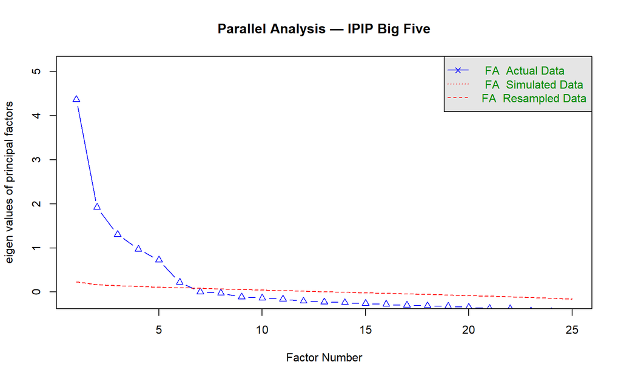

```
## Parallel analysis suggests that the number of factors =  6  and the number of components =  NA
```

```r
set.seed(2024)
pa <- fa.parallel(
  bfi_complete,
  fa      = "fa",        # factor analysis, not PCA
  fm      = "minres",    # minimum residual extraction
  n.iter  = 500,         # number of random simulations
  main    = "Parallel Analysis — IPIP Big Five"
)
```

```r
cat("\nParallel analysis recommends:", pa$nfact, "factors\n")
```

```
##
## Parallel analysis recommends: 6 factors
```

```r
cat("\nHow to read the plot:\n")
```

```
##
## How to read the plot:
```

```r
cat("  Solid line = your actual eigenvalues\n")
```

```
##   Solid line = your actual eigenvalues
```

```r
cat("  Dashed line = eigenvalues from random (simulated) data\n")
```

```
##   Dashed line = eigenvalues from random (simulated) data
```

```r
cat("  Retain factors where solid > dashed (to the left of where lines cross)\n")
```

```
##   Retain factors where solid > dashed (to the left of where lines cross)
```

**Why not the eigenvalue > 1 rule?** The classic Kaiser criterion says retain factors with eigenvalue > 1. With 25 items this typically suggests 6–8 factors — almost always too many. The rule has no theoretical basis and is known to over-extract. Use parallel analysis instead.

## 4.3 Step 3 — Run EFA

Key decisions: - **Extraction method:** We use `minres` (minimum residual) — it minimises off-diagonal residuals, does not assume multivariate normality, and is robust to non-normality. - **Rotation:** We use `oblimin` (oblique) — it allows factors to correlate, which is realistic for personality traits and most social science constructs. If you assume traits are uncorrelated, use `varimax` (orthogonal).

```r
# Fit 5-factor EFA (expected Big Five solution)
efa5 <- fa(
  r         = bfi_complete,
  nfactors  = 5,
  rotate    = "oblimin",    # oblique: factors can correlate
  fm        = "minres",
  scores    = "regression"  # compute factor scores for each respondent
)

# Print full output with cut = 0.30 (suppress loadings below |.30| for clarity)
print(efa5, cut = 0.30, sort = TRUE, digits = 2)
```

```
## Factor Analysis using method =  minres
## Call: fa(r = bfi_complete, nfactors = 5, rotate = "oblimin", scores = "regression",
##     fm = "minres")
## Standardized loadings (pattern matrix) based upon correlation matrix
##    item   MR2   MR1   MR3   MR5   MR4   h2   u2 com
## N1   16  0.83                         0.68 0.32 1.1
## N2   17  0.78                         0.61 0.39 1.0
## N3   18  0.70                         0.54 0.46 1.1
## N5   20  0.48                         0.35 0.65 2.0
## N4   19  0.47  0.40                   0.51 0.49 2.3
## E2   12        0.67                   0.55 0.45 1.1
## E4   14       -0.59                   0.54 0.46 1.5
## E1   11        0.55                   0.35 0.65 1.2
## E5   15       -0.42                   0.41 0.59 2.7
## E3   13       -0.41              0.30 0.44 0.56 2.7
## C2    7              0.67             0.45 0.55 1.2
## C4    9             -0.64             0.48 0.52 1.1
## C3    8              0.57             0.32 0.68 1.1
## C5   10             -0.56             0.44 0.56 1.4
## C1    6              0.55             0.35 0.65 1.2
## A3    3                    0.68       0.54 0.46 1.1
## A2    2                    0.66       0.46 0.54 1.0
## A5    5                    0.54       0.47 0.53 1.5
## A4    4                    0.45       0.30 0.70 1.7
## A1    1                   -0.44       0.20 0.80 1.9
## O3   23                          0.62 0.47 0.53 1.2
## O5   25                         -0.54 0.30 0.70 1.2
## O1   21                          0.52 0.32 0.68 1.1
## O2   22                         -0.47 0.27 0.73 1.7
## O4   24        0.33              0.36 0.25 0.75 2.6
##
##                        MR2  MR1  MR3  MR5  MR4
## SS loadings           2.58 2.21 2.10 2.07 1.64
## Proportion Var        0.10 0.09 0.08 0.08 0.07
## Cumulative Var        0.10 0.19 0.28 0.36 0.42
## Proportion Explained  0.24 0.21 0.20 0.20 0.15
## Cumulative Proportion 0.24 0.45 0.65 0.85 1.00
##
##  With factor correlations of
##       MR2   MR1   MR3   MR5   MR4
```

[output cut: 12 more lines]

```
## The root mean square of the residuals (RMSR) is  0.03
## The df corrected root mean square of the residuals is  0.04
##
## The harmonic n.obs is  2436 with the empirical chi square  565.95  with prob <  3.1e-40
## The total n.obs was  2436  with Likelihood Chi Square =  1538.52  with prob <  8.6e-212
##
## Tucker Lewis Index of factoring reliability =  0.877
## RMSEA index =  0.055  and the 90 % confidence intervals are  0.052 0.057
## BIC =  95.87
## Fit based upon off diagonal values = 0.98
## Measures of factor score adequacy
##                                                    MR2  MR1  MR3  MR5  MR4
## Correlation of (regression) scores with factors   0.91 0.82 0.84 0.83 0.82
## Multiple R square of scores with factors          0.83 0.67 0.71 0.68 0.66
## Minimum correlation of possible factor scores     0.66 0.34 0.43 0.36 0.33
```